# **Addition Insights - Semiconductor People-based Prospects**

March 15, 2022

[figure not shown]

## **ONiO**

**Company:** ONiO  
**Country (Operating):** Lille Grensen 3, 0159 Oslo, Norway  
**Founded Date:** January 01, 2016  
**Homepage:** http://onio.com  
**Current Headcount:** 18  
**Lifetime Funding:** $864,000  
**Number of Funding Rounds:** 4  
**Investors:** Investinor, Momentum Partners AS  
**Most Recent Funding:** SERIES A - November 26, 2021  
**Sectors:** Next Gen Computing, IoT, Microprocessing / Computing, Financial Technology, Health / Wellness, Energy / Sustainability / Natural Resources, Hardware  
**Description:** ONiO is a fabless IoT company specialising in batteryless microcontrollers that run on ambient energy. We are deeply committed to crafting viable clean-energy solutions for IoT devices, breaking them free from the battery. ONiO.zero is our line of batteryless general-purpose microcontrollers. ONiO.zero can use virtually any RF, thermal, solar, piezo signal as a power source. Our aim is to unshackle one IoT device at a time from the battery, en route to a 100% battery-free IoT future. Our product offers manufacturers a more minimalist, user-friendly, economical and environmentally sustainable power solution for IoT devices.

### **Headcount**

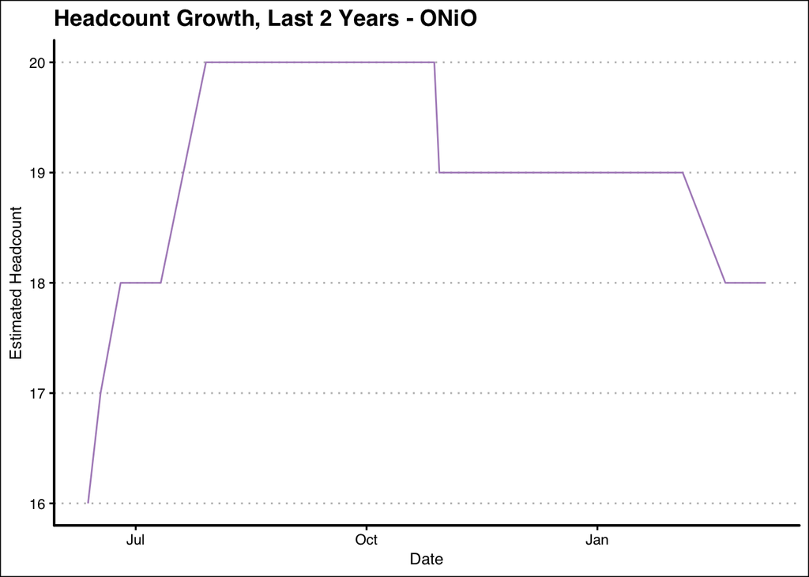

## **Vidatronic, Inc**

**Company:** Vidatronic, Inc  
**Country (Operating):** 6207 Bee Cave Road, Suite 140, Austin, TX 78746, United States  
**Founded Date:** January 01, 2010  
**Homepage:** http://vidatronic.com  
**Current Headcount:** 39  
**Lifetime Funding:** $3,514,300  
**Number of Funding Rounds:** 8  
**Investors:** Narwhal Ventures 🌊  
**Most Recent Funding:** LATER STAGE VC - February 10, 2020  
**Sectors:** Next Gen Computing, Microprocessing / Computing, IoT, Consumer Electronics, Hardware  
**Description:** Vidatronic specializes in enhancing the efficiency and performance of the world’s electronic devices by licensing analog intellectual property (IP) cores for integration into systems on a chip (SoCs), including integrated power management unit (PMU) solutions, analog circuitry, security IP, and other technology development projects. Vidatronic’s capabilities help customers achieve product feature and performance advantages, while their service gets them to market faster and their experience reduces overall risk. The company has patented, industry-leading technologies and features that allow their customers to reduce required board area and cost, while maintaining the desired low-noise and low quiescent current performance in a variety of applications from consumer electronics, including mobile, wireless, IoT and NB-IoT, to enterprise and servers. Vidatronic’s IP portfolio includes low dropout (LDO) voltage regulators, DC-DC converters, high-accuracy/low-power voltage references, LED drivers, and associated circuitry in a variety of advanced-process nodes, down to 5 nm. For more information visit www.vidatronic.com.

### **Headcount**

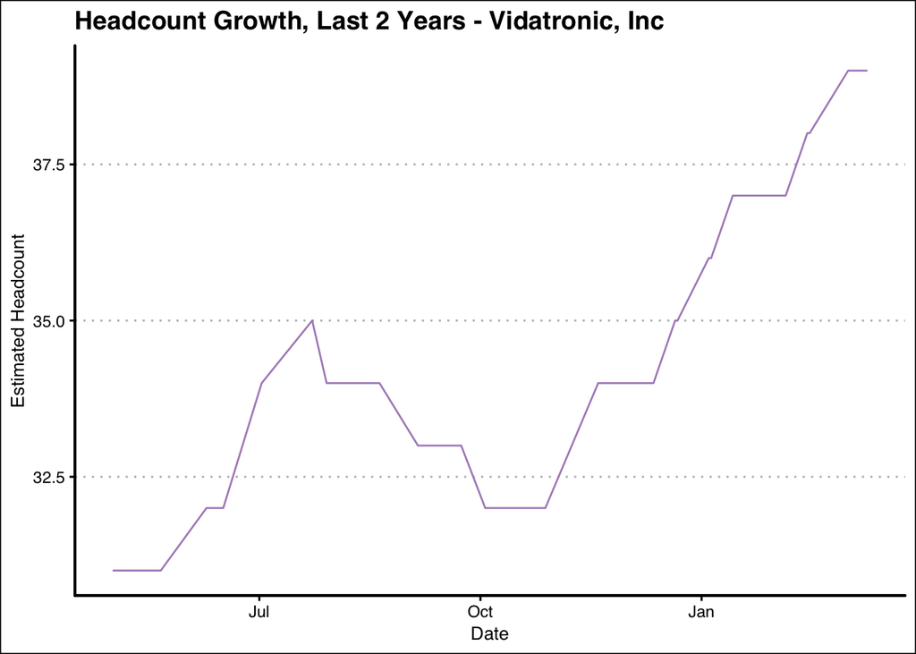

## **proteanTecs**

**Company:** proteanTecs  
**Country (Operating):** Haifa, Hefa, Israel  
**Founded Date:** January 01, 2017  
**Homepage:** http://proteantecs.com  
**Current Headcount:** 144  
**Lifetime Funding:** $147,000,000  
**Number of Funding Rounds:** 3  
**Investors:** Advantest, Atreides Management, LP, Valor Equity Partners, Zeev Ventures, Mitsubishi UFJ Capital Co.,Ltd., Champion Motors, Koch Disruptive Technologies, Redline Capital, ITI Venture Capital Partners, Porsche Automobil Holding SE, Regah Ventures, Avigdor Willenz, MediaTek Ventures, Viola Ventures, Celesta Capital, Intel Capital, Intel Corporation, Roy Oron  
**Most Recent Funding:** SERIES C - September 23, 2021  
**Sectors:** AI / ML, SaaS  
**Description:** At proteanTecs, we’re on a mission to enable the electronics industry to continue scaling. proteanTecs is a dynamic fast-paced start-up company, transforming the way reliability of electronics is achieved. In a world where machines are gaining immense responsibility over our lives, sudden failure is not an option. proteanTecs has developed a cloud-based platform, which combines data created in chip-embedded Agents, with machine learning, to predict faults before they become failures. Our solutions provide unprecedented insights throughout the value chain, from Chip Vendors to System Vendors and Digital Service Providers. The company was founded by seasoned industry veterans, including three former founders of Mellanox Technologies, with deep knowledge and experience in the electronics industry and is backed by worldwide leading investors. At proteanTecs we combine different disciplines in creating a revolutionary solution. Our team is highly interdisciplinary, ranging from SaaS and Machine Learning experts, to top designers in Chips and Circuits, as well as masters of EDA. We work together and learn from each other. We are looking for the best people to join the ride as we spearhead the next revolution in electronics!

### **Headcount**

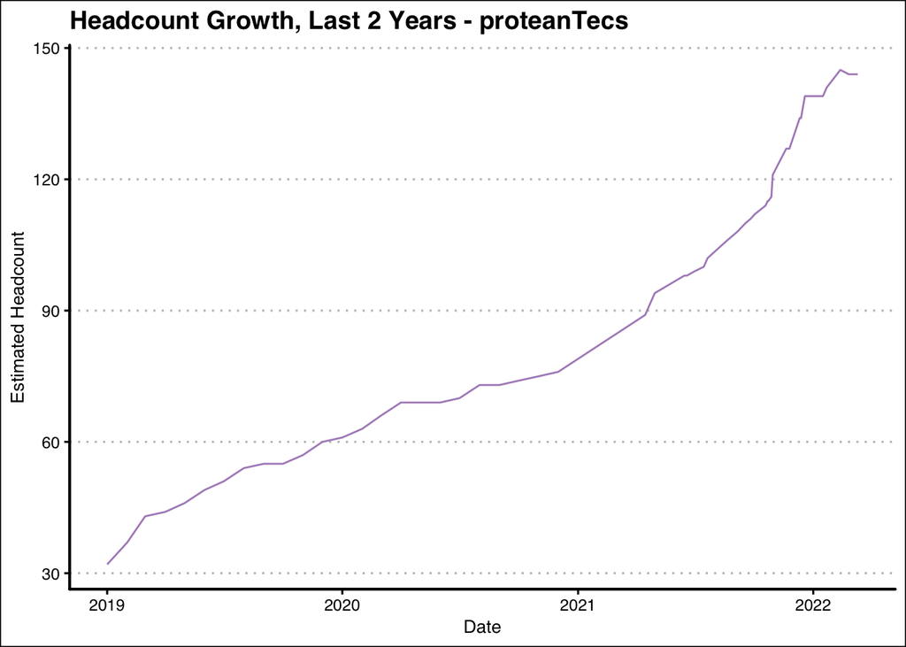

## **Chain Reaction Ltd.**

### **Headcount**

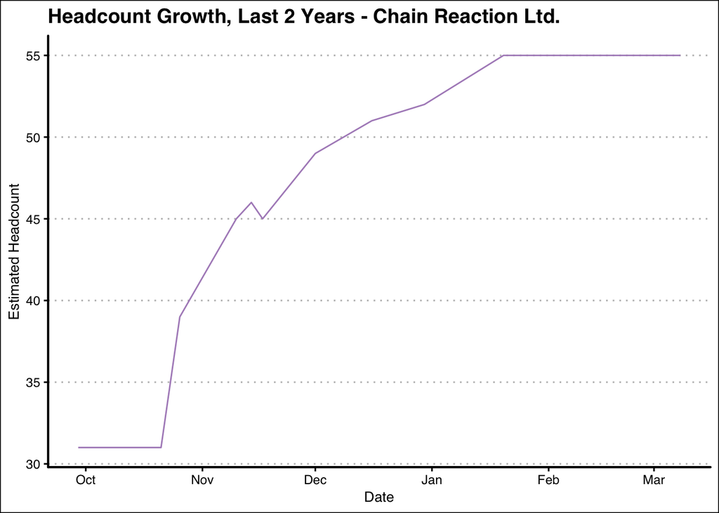

## **Celera Incorporated**

**Company:** Celera Incorporated  
**Country (Operating):** 3031 Tisch Way, Suite 110 Plaza West, San Jose, CA 95128, United States  
**Founded Date:** January 01, 2018  
**Homepage:** https://celeratechnologies.com  
**Current Headcount:** 19  
**Lifetime Funding:** $8,000,000  
**Number of Funding Rounds:** 2  
**Investors:** Valley Capital Partners  
**Most Recent Funding:** SEED - September 07, 2021  
**Sectors:** Microprocessing / Computing, Next Gen Computing, Hardware  
**Description:** Liberating the analog/mixed-signal IC industry by improving R&D efficiency 100X. Celera delivers the ‘impossible’: fully automated analog/mixed-signal IC development lightning fast and the push of a button. This unburdens the industry to pursue an estimated $30B in new profitable growth ushering the next generation of semiconductor devices: Silicon 3.0 - Move Fast and Build Things.

### **Headcount**

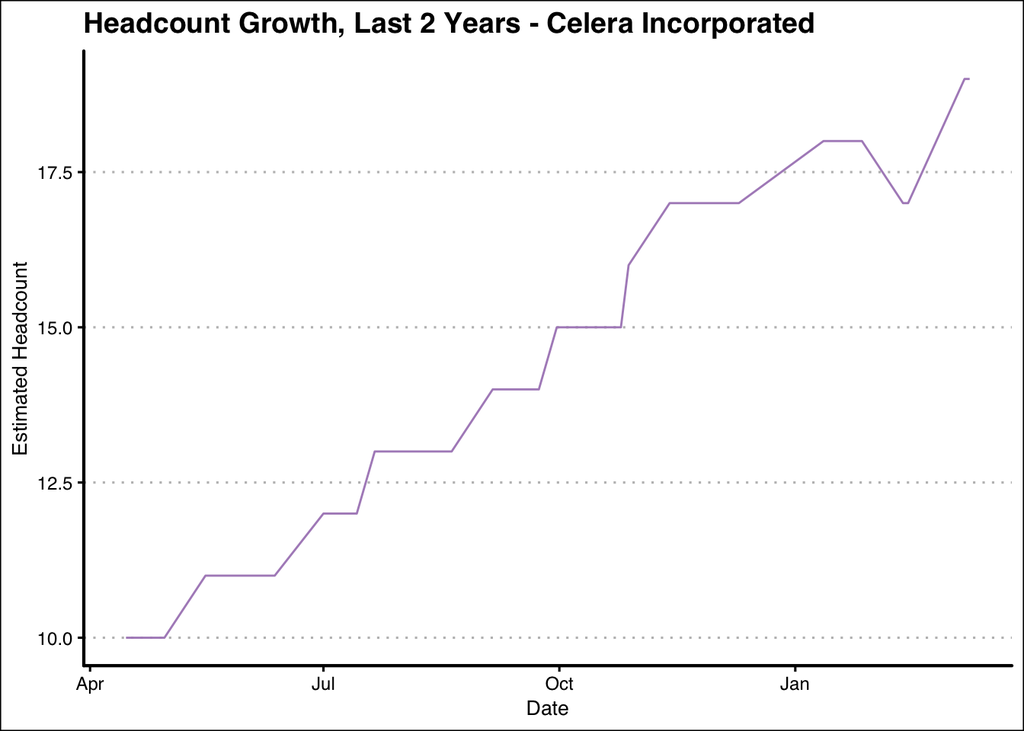

## **eXo Imaging Inc.**

**Company:** eXo Imaging Inc.  
**Country (Operating):** 3600 Bridge Parkway, Suite 102, Redwood City, CA 94065, United States  
**Founded Date:** January 01, 2015  
**Homepage:** http://exo.inc  
**Current Headcount:** 150  
**Lifetime Funding:** $307,500,000  
**Number of Funding Rounds:** 6  
**Investors:** OSF HealthCare, The Longevity Fund, Solasta Ventures, Creative Ventures, Reimagined Ventures, Magnetar Capital, Black Diamond Ventures, TDK Ventures, Nautilus Venture Partners, NALA Investments, Longevity Vision Fund, Rising Tide VC, Sands Capital, Pura Vida Investments, Wanxiang America Healthcare Investments Group, BOLD Capital Partners, RA Capital Management, L.P., Action Potential Venture Capital, Avidity Partners, AJU IB INVESTMENT, Fiscus Ventures, Blackrock Innovation Capital Group, BlackRock, Anti Fund Investment Fund, Intel Capital, Intel Corporation, Sony, Applied Materials  
**Most Recent Funding:** SERIES C - July 29, 2021  
**Sectors:** Next Gen Computing, Financial Technology, AI / ML, Health / Wellness, Medical Devices, Hardware  
**Description:** Exo (pronounced “Echo”) is a health information and devices company whose mission is to modernize medical imaging through its high-performance handheld ultrasound platform and artificial intelligence, enabling healthcare professionals to make critical, real-time decisions that ultimately improve patient outcomes. The Exo ultrasound platform combines advances in nano-materials, novel sensor technologies, advanced signal processing and computation with the economies of scale of semiconductor manufacturing to dramatically reduce the cost of imaging.

### **Headcount**

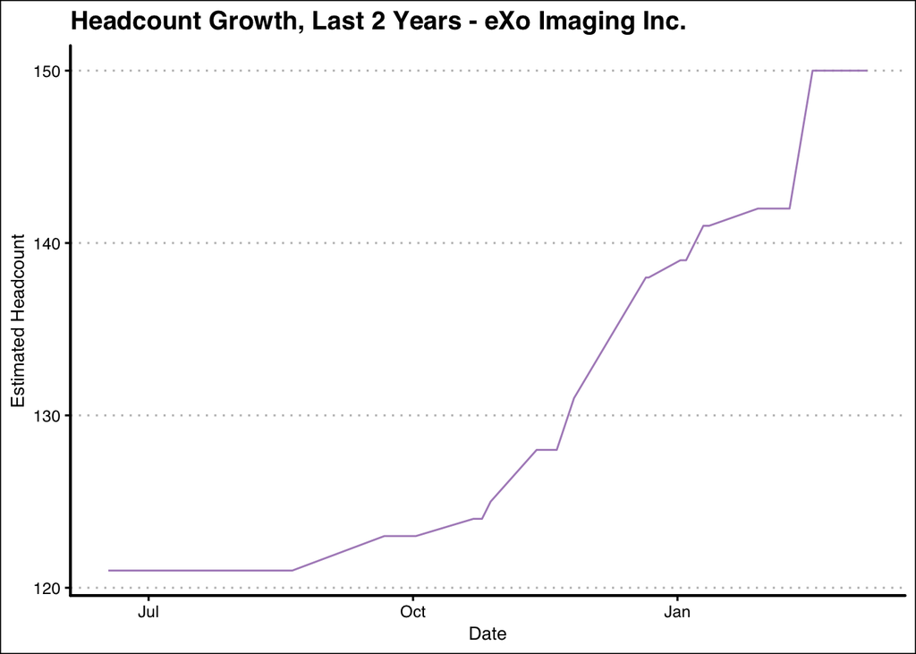

## **Presto Engineering**

**Company:** Presto Engineering  
**Country (Operating):** Rue De La Carrière De Bachasson, Arteparc Bachasson, 13590 Meyreuil, France  
**Founded Date:** January 01, 2006  
**Homepage:** http://presto-eng.com  
**Current Headcount:** 120  
**Lifetime Funding:** $8,000,000  
**Number of Funding Rounds:** 3  
**Investors:** Seventure Partners, CM-CIC Capital Privé, Adaxtra, Bpifrance  
**Most Recent Funding:** SERIES UNKNOWN - December 12, 2018  
**Sectors:** Next Gen Computing, IoT, Hardware  
**Description:** Presto Engineering provides ASIC design and outsourced operations for semiconductor and IoT device companies, helping its customers minimize overhead, reduce risk, and accelerate time-to-market. The company is a recognized expert in the development of industrial solutions for RF, analog, mixed-signal, and secured applications – from design, tape-out to delivery of finished goods. Presto’s proprietary, highly-secure manufacturing and provisioning solution, coupled with extensive back-end expertise, gives its customers a competitive advantage. The company offers a global, flexible, dedicated framework, with headquarters in Meyreuil, France, and operations across Europe, North America, and Asia. For more information, visit: www.presto-eng.com.

### **Headcount**

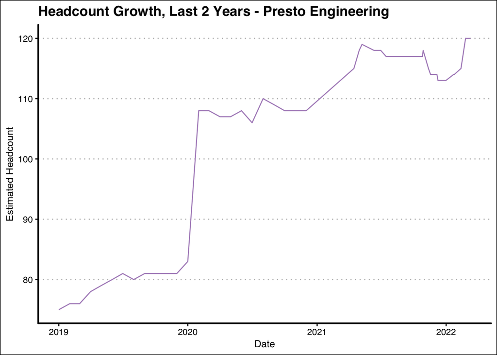

## **Elastics.cloud, Inc.**

**Company:** Elastics.cloud, Inc.  
**Country (Operating):** 1730 North First Street, 5th Floor, San Jose, CA 95112, United States  
**Founded Date:** January 01, 2021  
**Homepage:** https://elastics.cloud  
**Current Headcount:** 17  
**Lifetime Funding:** $6,000,000  
**Number of Funding Rounds:** 1  
**Investors:** Sehat Sutardja, Weili Dai  
**Most Recent Funding:** SEED - July 08, 2021  
**Sectors:** Next Gen Computing, Microprocessing / Computing, Hardware  
**Description:** Elastics.cloud, Inc. is a semiconductor, hardware and software systems company embarking on a long-term vision of enabling composable architectures. As requirements continue to rise for improved component utilization and overall system performance, more flexible solutions are required to address a heterogeneous workload environment. In an emerging tiered data center model, scalability and TCO are the critical factors needed to be addressed by low-latency processing. We are a next-generation infrastructure company addressing a very large $500 billion dollar market composed of on-prem, edge data center, and core data center equipment.

### **Headcount**

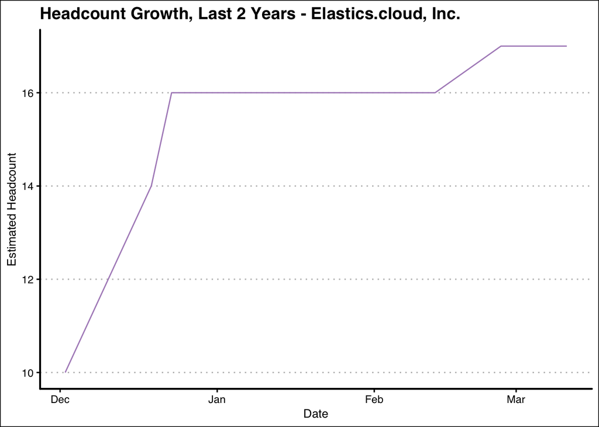

## **zGlue**

**Company:** zGlue  
**Country (Operating):** Mountain View, California, United States  
**Founded Date:** January 01, 2014  
**Homepage:** https://zglue.com  
**Current Headcount:** 15  
**Lifetime Funding:** $9,100,000  
**Number of Funding Rounds:** 2  
**Investors:** CNBC, StartX., Skywood Capital 天木资本, BOE Technology Group Co., Ltd., National Science Foundation (NSF), Houd Tide Investment 汇中泰德, National Institute of Mental Health (NIMH), Q Venture Partners, Sonny Vu, KhengNam Lee  
**Most Recent Funding:** SERIES A - January 30, 2019  
**Sectors:** Microprocessing / Computing, Next Gen Computing, Platform Software, Consumer Electronics, AI / ML, Hardware  
**Description:** zGlue is a Silicon Valley company offering a platform and process for building custom chips on demand. As businesses in the hardware space face increasingly intense time-to-market challenges, zGlue provides an innovative solution through their ChipBuilder software platform, proprietary Smart Fabric™ interposer, and manufacturing partnerships with world-renowned TSMC and ASE. zGlue’s approach to accelerated product development delivers top-quality chips at an exceptional speed, offering significant improvement in miniaturization, affordability, and scalability for custom ICs.

### **Headcount**

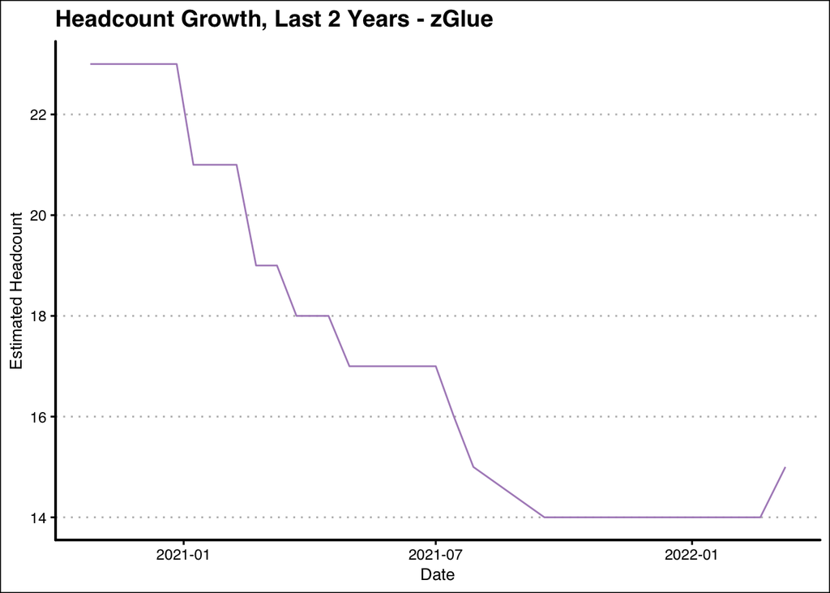

## **Nebula Microsystems Inc.**

**Company:** Nebula Microsystems Inc.  
**Country (Operating):** 801 East Campbell Road, Suite 460, Richardson, TX 75081, United States  
**Founded Date:** January 01, 2020  
**Homepage:** http://nebmicro.com  
**Current Headcount:** 44  
**Lifetime Funding:** $15,000,000  
**Number of Funding Rounds:** 1  
**Investors:** MORNING SIDE  
**Most Recent Funding:** SEED - March 30, 2021  
**Sectors:** Microprocessing / Computing, Next Gen Computing, Hardware  
**Description:** Nebula Microsystems Inc’s mission is to deliver intelligent and high-performance Analog Products for a wide variety of applications to meet our worldwide customer requirements. Our solutions are focused on – but not limited to - Signal Chain and Power Applications for major markets with our expertise highlighted by extensive years of product developments. Our international team is located in technology focused areas that provide the technical talent required for this industry.

### **Headcount**

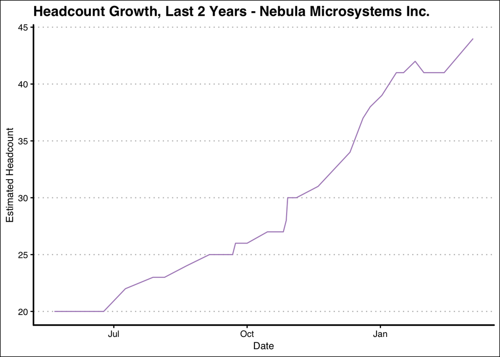

## **Xsight Labs LTD**

**Company:** Xsight Labs LTD  
**Country (Operating):** Kiryat Gat, HaDarom, Israel  
**Founded Date:** January 01, 2017  
**Homepage:** https://xsightlabs.com  
**Current Headcount:** 135  
**Lifetime Funding:** $191,000,000  
**Number of Funding Rounds:** 5  
**Investors:** Atreides Management, LP, Valor Equity Partners, M12 - Microsoft’s Venture Fund, Battery Ventures, A&E Investments, Accton, Fidelity Management & Research, Fidelity Investments, Avigdor Willenz, Xilinx, Intel Capital, Microsoft, Manuel Alba, Orly Tsioni, zvi limon  
**Most Recent Funding:** SERIES D - March 03, 2021  
**Sectors:** Microprocessing / Computing, Cloud Infrastructure, Enterprise Cloud Infrastructure, Next Gen Computing, Hardware  
**Description:** Xsight Labs is a fabless semiconductor company headquartered in Kiryat Gat, Israel with additional offices in Tel-Aviv and Binyamina. In the United States, Xsight Labs has offices in Boston, MA, Raleigh, NC and San Jose, CA. Founded in 2017, Xsight Labs has a bold vision to re-architect the foundation of cloud infrastructure by delivering a broad portfolio of products to enable end-to-end connectivity. Xsight Labs’ breakthrough technology delivers exponential bandwidth growth while reducing power and total cost of ownership. Xsight Labs is proud to have assembled a world-class engineering team with the goal of enabling next-generation end-to-end data center interconnect and driving new paradigms of scale and efficiency. Building on over 20 years of experience in developing and productizing multiple generations of cloud infrastructure products the Xsight Labs executive team is focused on tackling modern data center challenges in unique ways that will revolutionize how customers architect the data centers of tomorrow.

### **Headcount**

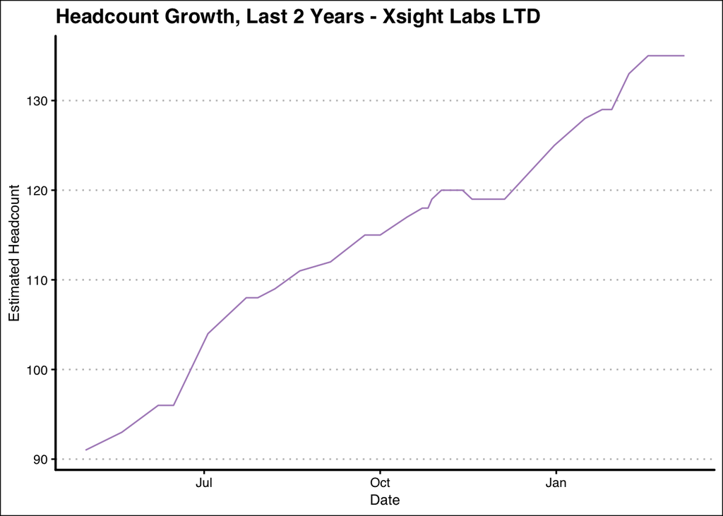

## **USound GmbH**

**Company:** USound GmbH  
**Country (Operating):** Kratkystraße 2, Graz, 8020, Austria  
**Founded Date:** January 01, 2012  
**Homepage:** http://usound.com  
**Current Headcount:** 55  
**Lifetime Funding:** $79,010,452  
**Number of Funding Rounds:** 7  
**Investors:** EuroUS Ventures, eQventure, Science Park Graz (SPG), European Investment Bank (EIB), European Commission, Hermann Hauser, Horizon 2020, Gregory Galvin, Ignazio Rusconi-Clerici, Longzhong Yang  
**Most Recent Funding:** SERIES D - December 17, 2021  
**Sectors:** Wearables, Next Gen Computing, Voice Messaging, Microprocessing / Computing, Hardware  
**Description:** USound is a fabless audio company offering high-performance silicon speakers and high-quality sound solutions based on MEMS (Micro-Electro-Mechanical Systems) technology. It is our vision to inspire music enthusiasts and acoustic professionals with crisp, natural sound for a fantastic hearing experience. With our headquarters in Graz and Vienna (Austria), as well as planned offices in California and Shanghai, we serve international customers, enabling them to create smart audio applications with our MEMS speakers. Our products are smart components designed to fit seamlessly into earphones, headphones, hearables, wearables, and smartphones. Our micro speakers are power-management friendly and programmable for the best efficiency in a wide range of working conditions. We imagine a future where speakers and microphones are connected together into smart audio systems. With the introduction of innovative MEMS technology, we are setting new standards in terms of audio experience and low power consumption.

### **Headcount**

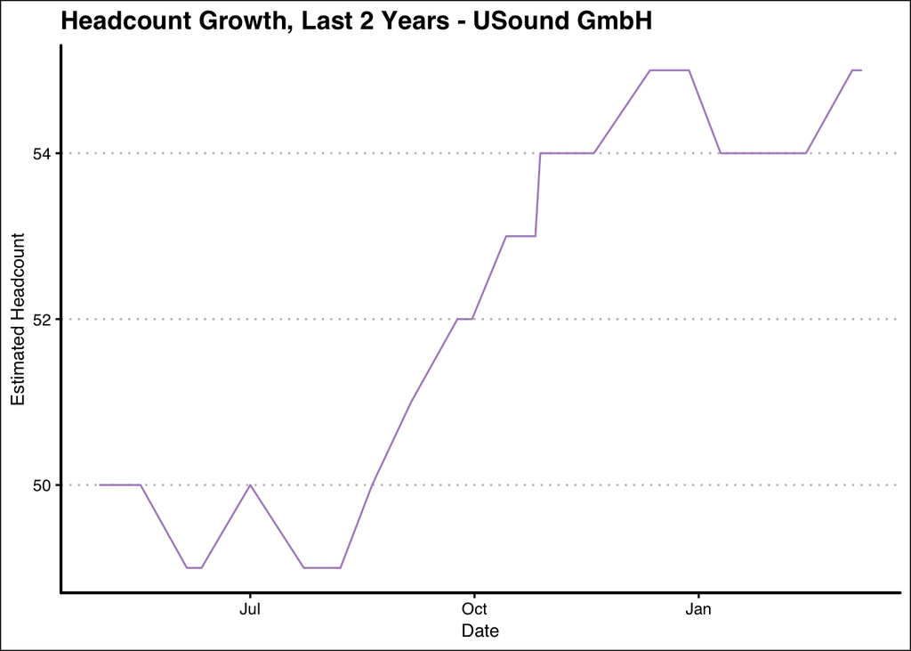

## **Calterah Semiconductor 加特兰微电子科技**

**Company:** Calterah Semiconductor 加特兰微电子科技  
**Country (Operating):** Shanghai, Shanghai, China  
**Founded Date:** January 01, 2014  
**Homepage:** https://calterah.com  
**Current Headcount:** 46  
**Lifetime Funding:** $4,931,527  
**Number of Funding Rounds:** 10  
**Investors:** 广汽资本有限公司, FreeS Fund 峰瑞资本, Shang Qi Capital, China Merchants Capital, 上海君桐股权投资管理有限公司, Fosun 复星, Everest Capital LMFVC, Gopher Asset, China Capital Investment Group, Green Harbor Investments 盈港资本, Zhongguancun Xingye Investment, Shanxi Hongchuang, Xianggang Ziteng, Silergy, China Renaissance 华兴资本, CICC Jia Cheng Investment Management Company, Shenzhen Juntong Capital Investment Management  
**Most Recent Funding:** SERIES C - January 20, 2022  
**Sectors:** Next Gen Computing, Microprocessing / Computing, Automotive, Hardware  
**Description:** Calterah Semiconductor is a fabless semiconductor startup founded by pioneers in the field of high frequency CMOS from the University of California, Berkeley and the Silicon Valley. The company focuses on developing high performance sensor technology for Advanced Driver Assistance Systems (ADAS) and various autonomous vehicles. It aims to be a leading semiconductor technology company worldwide, with a mission to provide affordable safe mobility for the mass market. The startup is backed by top tier semiconductor venture capital firms.

### **Headcount**

[figure not shown]

## **Bravotek Electronics**

**Company:** Bravotek Electronics  
**Country (Operating):** Zhubei City, , Hsinchu County  
**Founded Date:** January 01, 2017  
**Homepage:** https://www.bravotekcorp.com/en  
**Current Headcount:** 4  
**Lifetime Funding:**  
**Number of Funding Rounds:** 1  
**Investors:** UMC Capital 宏誠創投  
**Most Recent Funding:** EARLY STAGE VC - May 10, 2021  
**Sectors:** Next Gen Computing, Microprocessing / Computing, Hardware  
**Description:** An Creative Analog and Power IC Company

### **Headcount**

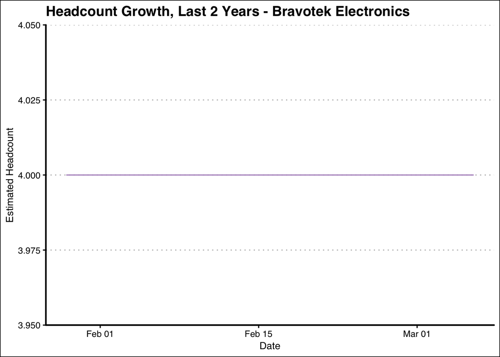

## **Menlo Micro**

**Company:** Menlo Micro  
**Country (Operating):** 49 Discovery, Suite 150, Irvine, CA 92618, United States  
**Founded Date:** January 01, 2016  
**Homepage:** https://menlomicro.com  
**Current Headcount:** 48  
**Lifetime Funding:** $227,700,000  
**Number of Funding Rounds:** 4  
**Investors:** Piva Capital, Future Shape LLC, Sierra Ventures, Paladin Capital Group, PeopleFund Inc., 40 North Ventures, Fidelity Management & Research, Corning, Vertical Venture Partners, DBL Partners, GE Power, Microsemi Corporation, Bradley Horowitz, Matias de Tezanos  
**Most Recent Funding:** SERIES C - March 09, 2022  
**Sectors:** Next Gen Computing, Microprocessing / Computing, Consumer Electronics, Automotive, Energy / Sustainability / Natural Resources, Hardware  
**Description:** Menlo Micro is reimagining one of the most fundamental building blocks of electronic systems – the electronic switch. The company’s Digital-Micro-Switch platform is a game changer for those who design electronic systems, with a market opportunity of more than $5 billion. It has the potential to serve multiple industries, including: next generation 5G mobile networks, industrial IOT markets, battery management, home-automation, electronic vehicles and medical instrumentation. The electromechanical switch technology hasn’t experienced innovation in the past 25 years. As a result, the size, weight, cost and performance of electronic switch technologies has hindered system designer’s ability to create high performance and reliable products ranging from battery chargers to electric vehicles. Menlo Micro has lifted these limitations by developing unique materials, designs, and processing techniques to build an enhanced electronic switch that can handle high temperature, high-stress conditions for products that require decades of useful life. The new switch operates up to 1000x faster than a typical mechanical switch, can handle hundreds of Watts of power and is built in a structure smaller than a human hair. Menlo Micro is backed by GE Ventures, with strategic investments from Corning, Microsemi Paladin Capital Group. GE has invested over 12 years of R&D into the Digital-Micro-Switch technology, producing 60 patent families and a series of GE-qualified DMS products. Now, Menlo Micro will focus on bringing this unique solution to the broader market, expanding development of the technology and its reach across industries.

### **Headcount**

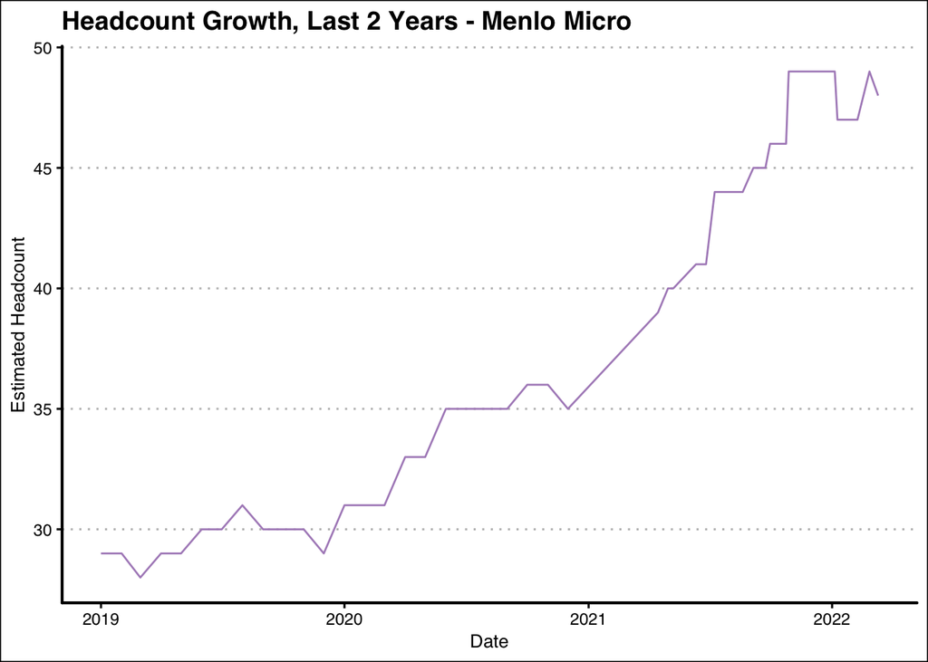

## **Credo Semiconductor**

**Company:** Credo Semiconductor  
**Country (Operating):** San Jose, California, United States  
**Founded Date:** January 01, 2008  
**Homepage:** https://credosemi.com  
**Current Headcount:** 216  
**Lifetime Funding:** $126,000,000  
**Number of Funding Rounds:** 6  
**Investors:** 华登国际投资, A&E Investments, BlackRock, Celesta Capital  
**Most Recent Funding:** IPO - May 13, 2021  
**Sectors:** Next Gen Computing, Microprocessing / Computing, Cloud Infrastructure, Enterprise Cloud Infrastructure, Data Analytics, Hardware  
**Description:** cre·do (ˈkrēdō,ˈkrādō): “I believe” Credo’s mission is to deliver high-speed solutions to break bandwidth barriers on every wired connection in the data infrastructure market. We were founded in 2008 by a seasoned team of analog, digital, and mixed-signal experts as a fabless semiconductor company. Our innovations ease system bandwidth bottlenecks and our strong SerDes IP portfolio is the foundation for our high-performance, power-efficient, and cost-effective connectivity solutions. Credo has a history of innovation and pioneering new technologies. We believe this positions us to deliver best-in-class products and IP solutions that address our customers’ various bandwidth, power, cost, security, reliability, and end-to-end signal integrity requirements. Our engineering-focused workforce and highly technical management team have deep industry experience and connectivity expertise. The team continues to grow with offices North America and Asia.

### **Headcount**

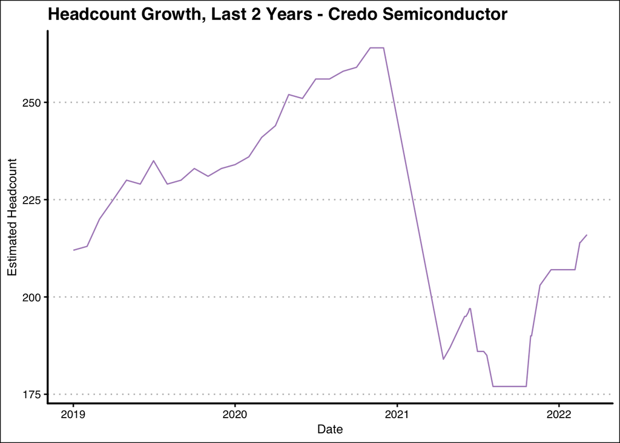

## **Wise-integration**

**Company:** Wise-integration  
**Country (Operating):** Domaine du petit Arbois, Avenue Louis Philibert, 13100 Aix en Provence, France  
**Founded Date:** January 01, 2019  
**Homepage:** https://www.wise-integration.com  
**Current Headcount:** 13  
**Lifetime Funding:** $3,180,000  
**Number of Funding Rounds:** 1  
**Investors:** Région Sud Investissement, Foreis, Crédit Agricole Alpes Développement  
**Most Recent Funding:** EARLY STAGE VC - September 27, 2021  
**Sectors:** Next Gen Computing, Microprocessing / Computing, Hardware  
**Description:** Wise-integration is a fabless company providing power GaN integrated circuit with digital control to reach ultimate customers power supplies performances with a simple design : smaller size, better efficiency and more reliability at low et cost

### **Headcount**

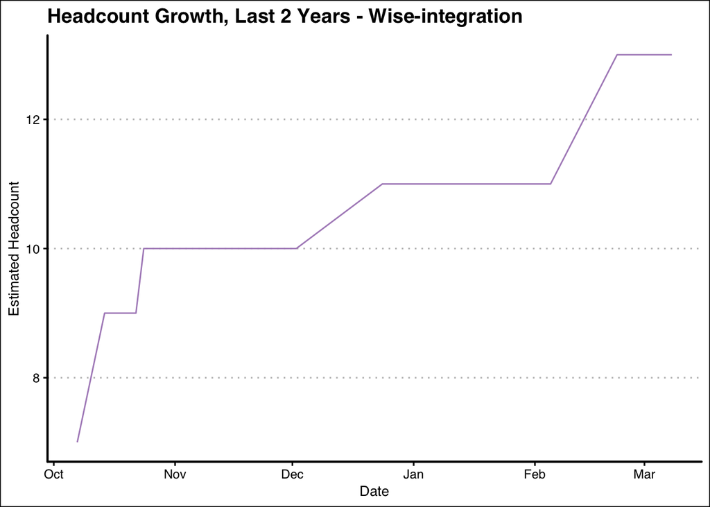